# TP1 commencer avec R

Frédérique Leblanc

2024

Pour configurer l’environnement RMarkdown et fixer les tailles de graphiques

```r
knitr::opts_chunk$set(fig.height=2.5, fig.width=4,fig.align="center")
```

## Exercice 1

Pour travailler dans le répertoire de travail TP1 on utilise l’instruction suivante $\texttt{setwd("~/...../TP1")}$ ou on demande à R d’exécuter le chagement de répertoire de travail via le menu **Session/Set Working Directory/Choose Directory**.

### question 5

Executer l’instruction suivante en cliquant sur la petite flèche verte orientée vers la droite et située en haut à droite de la partie grisée contenant une série d’instructions :

```r
1:10
```

```
##  [1]  1  2  3  4  5  6  7  8  9 10
```

Observer que l’instructions exécutée est rappelée dans la fenêtre Console après le prompt “>” en bleue et que son résultat s’affiche en noir.

### question 6

On peut ajouter des commentaires dans un tronçon grisé contenant des instructions en les précédant du caractère ‘#’. Sinon toutes les parties rédigées sur fond blanc sont du texte (avec possibilité d’y intégrer des formules mathématiques). Les parties (encadrées sur fond blanc en html) précédées d’un double ‘#’ sont le résultats des instructions indiquées dans la partie grisée.

```r
init<-1:10  #affecte à init la liste des 10 premiers entiers
1:10-> init # meme chose que précédemment
init=1:10 # autre option pour définir un objet mais préférer les deux premières
init # affiche le contenu de l'objet
```

```
##  [1]  1  2  3  4  5  6  7  8  9 10
```

### question 7

On peut appeler la fonction d’aide de R sur une fonction avec la fonction help() de R, par exemple pour comprendre ce que fait l’opérateur ‘:’ on exécute

```r
help(":")
```

## Exercice 7 : tracés de fonctions

### Inclure des graphiques

Par exemple pour tracer le nuage des points d’abscisses 1,2,3,4 et 5 et d’ordonnées 2,4,6,8 et 10 on utilise la fonction plot() et les instructions suivantes :

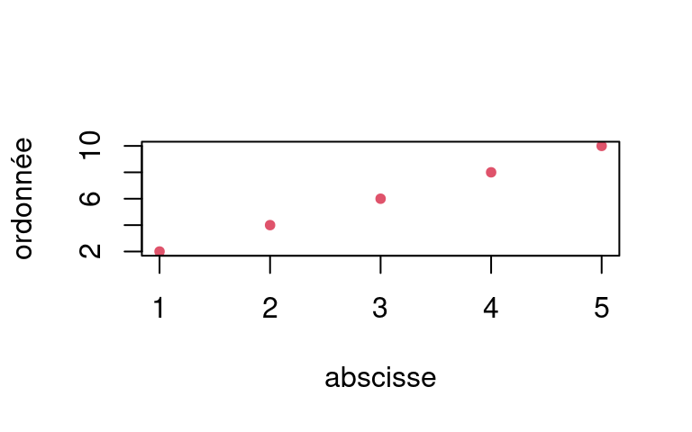

```r
x<-1:5
y<-2*x
plot(x,y,col=2,xlab="abscisse", ylab="ordonnée", pch=20)
```

Aller consulter l’aide de la fonction $\texttt{plot}$ pour personnaliser et améliorer ce graphique en y ajoutant par exemple un titre, en reliant les points par des segments,….